# Exercise2

Matthew Reynolds

2023-04-19

**Question:**  
We will now derive the probability that a given observation is part of a bootstrap sample. Suppose that we obtain a bootstrap sample from a set of n observations.

1. What is the probability that the first bootstrap observation is not the jth observation from the original sample? Justify your answer.

   The probability that the first bootstrap observation is not the jth observation from the origional sample is found with the equation: $\large \frac{n-1}{n}$. This is because each observation has an equal probability of being selected, and the jth observation has a probability of $\large\frac{1}{n}$ of being selected.
2. What is the probability that the second bootstrap observation is not the jth observation from the original sample?

   The probability that the second bootstrap observation is not the jth observation is the same as above, $\large \frac{n-1}{n}$
3. Argue that the probability that the jth observation is not in the bootstrap sample is (1 − 1/n)n.

   Since $\frac{n-1}{n}=1-\frac{1}{n}$ and that we bootstrap with $n$ draws, therefore the probability that it is not selected in a single bootstrap sample, is raised to the power of n. So our new equation is $(1 - \frac{1}{n})^n$
4. When n = 5, what is the probability that the jth observation is in the bootstrap sample?

   When $n = 5$ the probability that the jth observation is in the bootstrap sample is $(1 - \frac{1}{5})^5$ which equals to 67.23%.
5. When n = 100, what is the probability that the jth observation is in the bootstrap sample?

   When $n = 100$ the probability that the jth observation is in the bootstrap sample is $(1 - \frac{1}{100})^{100}$ which equals to 63.39%%.
6. When n = 10, 000, what is the probability that the jth observa- tion is in the bootstrap sample?

   When $n = 10,000$ the probability that the jth observation is in the bootstrap sample is $(1 - \frac{1}{10000})^{10000}$ which equals to 63.21%%.
7. Create a plot that displays, for each integer value of n from 1 to 100,000, the probability that the jth observation is in the bootstrap sample. Comment on what you observe.

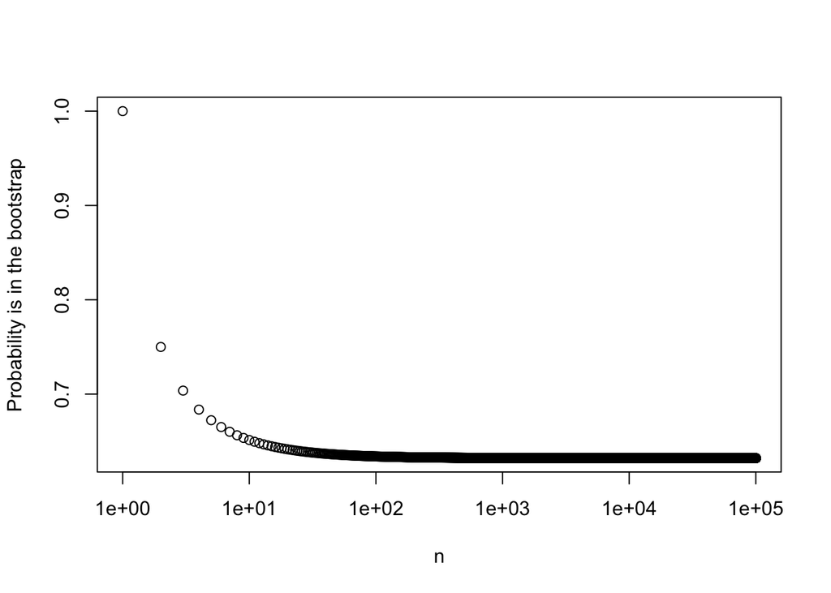

```r
x=seq(1,100000)
y=sapply(x,function(n){1-((1-(1/n))^n)})
plot(x,y,xlab="n",ylab="Probability is in the bootstrap",log="x")
```

The probability quickly drops to roughly 63% at a bit over 100 and plateaus there.

8. We will now investigate numerically the probability that a boot- strap sample of size n = 100 contains the jth observation. Here j = 4. We repeatedly create bootstrap samples, and each time we record whether or not the fourth observation is contained in the bootstrap sample.

```r
store=rep(NA, 10000)
for(i in 1:10000){
  store[i]=sum(sample(1:100, rep=TRUE)==4)>0
}
mean(store)
```

```
## [1] 0.6407
```